# KC scRNA-seq import and QC of placental villous tissue

# Single-cell RNA-seq analysis of KC and TNL Pique-Regi placental villous tissue samples

### Important References

Minimal QC recommended: Current best practices in single‐cell RNA‐seq analysis: a tutorial Orchestrating Single-cell Analysis ### Compiling Issues This document had trouble compiling via knitr and pandoc. The following thread fixed the issue (https://github.com/rstudio/rstudio/issues/3661). ## Create and merge Seurat objects from CellRanger count output Feature names cannot have underscores and are automatically replaced with dashes.

```r
# Function to convert from 10x output to seurat object with no filtering
tenx_to_seu <- function(counts.matrix, project.name) {
  CreateSeuratObject(counts = counts.matrix,
                     min.features=0, min.cells=0,
                     project = project.name)
}
# Apply function to each count matrix
kc40.1 <- tenx_to_seu(counts.matrix = readRDS(paste0(data_dir, "kc40_1_raw.rda")),
                      project.name = "kc40.1")
kc40.2 <- tenx_to_seu(counts.matrix = readRDS(paste0(data_dir, "kc40_2_raw.rda")),
                      project.name = "kc40.2")
kc42.1 <- tenx_to_seu(counts.matrix = readRDS(paste0(data_dir, "kc42_1_raw.rda")),
                      project.name = "kc42.1")
kc42.2 <- tenx_to_seu(counts.matrix = readRDS(paste0(data_dir, "kc42_2_raw.rda")),
                      project.name = "kc42.2")
# Merge
kc <- merge(kc40.1, y = c(kc40.2, kc42.1, kc42.2), add.cell.ids = c("kc40.1", "kc40.2", "kc42.1", "kc42.2"), project = "kc")
# Clean-up memory
rm(kc40.1, kc40.2, kc42.1, kc42.2)
```

```r
# Convert to SingleCellExperiment for QC
sce <- as.SingleCellExperiment(kc)
# Clean-up memory
rm(kc)
```

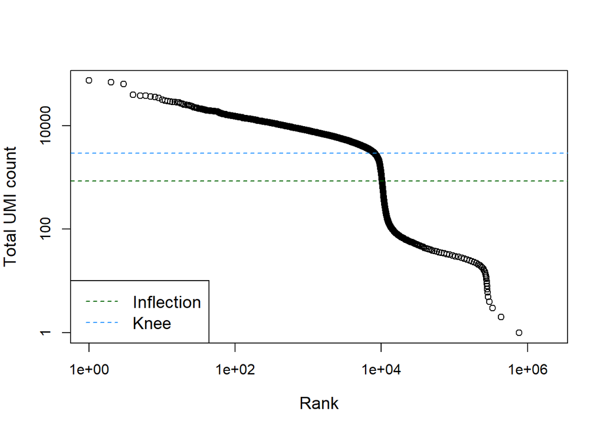

```r
bcrank <- barcodeRanks(counts(sce))
# Only showing unique points for plotting speed.
uniq <- !duplicated(bcrank$rank)
plot(bcrank$rank[uniq], bcrank$total[uniq], log="xy",
    xlab="Rank", ylab="Total UMI count", cex.lab=1.2)
abline(h=metadata(bcrank)$inflection, col="darkgreen", lty=2)
abline(h=metadata(bcrank)$knee, col="dodgerblue", lty=2)

legend("bottomleft", legend=c("Inflection", "Knee"),
        col=c("darkgreen", "dodgerblue"), lty=2, cex=1.2)
```

```r
# emptyDrops performs Monte Carlo simulations to compute p-values,
# so we need to set the seed to obtain reproducible results.
set.seed(1)
e.out <- emptyDrops(counts(sce))

# See ?emptyDrops for an explanation of why there are NA values.
summary(e.out$FDR <= 0.001)
```

```
##    Mode   FALSE    TRUE    NA's
## logical    4349    9812 2934959
```

```r
# Want to see 0 in the Sig FALSE, Limited TRUE cell. If not, increase MC simulations to reach 0
table(Sig=e.out$FDR <= 0.001, Limited=e.out$Limited)
```

```
##        Limited
## Sig     FALSE TRUE
##   FALSE  4349    0
##   TRUE   4872 4940
```

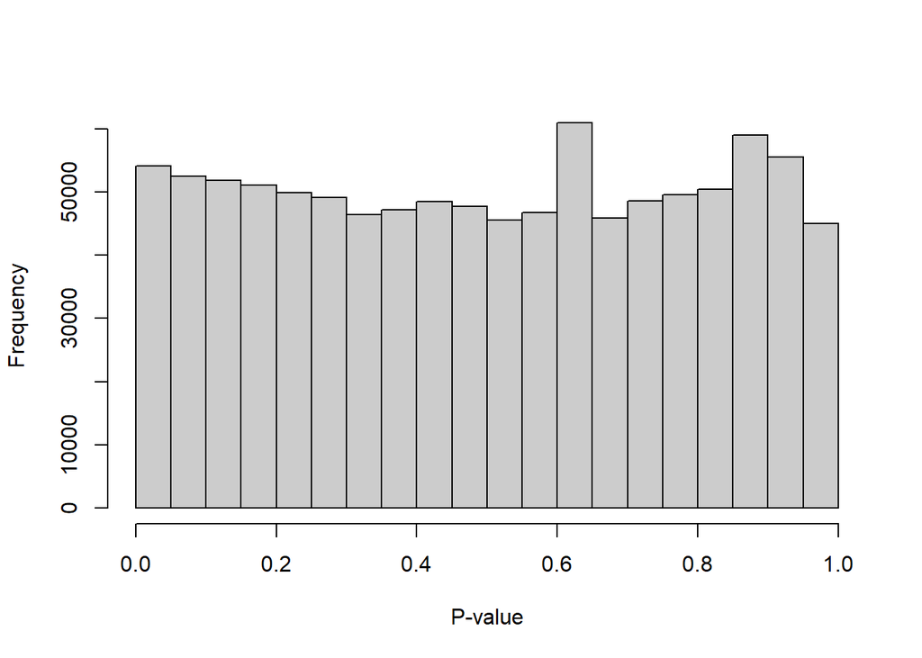

```r
set.seed(100)
limit <- 100
all.out <- emptyDrops(counts(sce), lower=limit, test.ambient=TRUE)
hist(all.out$PValue[all.out$Total <= limit & all.out$Total > 0],
    xlab="P-value", main="", col="grey80")
```

```r
# Drop empty droplets based on MC metrics above
sce <- sce[,which(e.out$FDR <= 0.001)]
# Memory clean-up
rm(bcrank, all.out, e.out)
```

## Calculate QC Metrics

Calculate %reads mapping to mitochondrial genes

```r
is.mito <- grepl("^MT-", rownames(sce))
sce <- addPerCellQC(sce, subsets=list(Mito=is.mito))
colnames(colData(sce))
```

```
##  [1] "orig.ident"            "nCount_RNA"            "nFeature_RNA"
##  [4] "ident"                 "sum"                   "detected"
##  [7] "subsets_Mito_sum"      "subsets_Mito_detected" "subsets_Mito_percent"
## [10] "total"
```

Perform outlier detection for unique RNA molecules, genes detected per cell, and percentage mitochondiral gene mapping.

```r
qc.lib <- isOutlier(sce$sum, log=TRUE, type="lower")
qc.nexpr <- isOutlier(sce$detected, log=TRUE, type="lower")
qc.mito <- isOutlier(sce$subsets_Mito_percent, type="higher")

print(paste0("Cells with less than ", ceiling(as.numeric(attr(qc.lib, "thresholds")["lower"])), " unique RNA molecules are outliers"))
```

```
## [1] "Cells with less than 1154 unique RNA molecules are outliers"
```

```r
print(paste0("Cells with less than ", ceiling(as.numeric(attr(qc.nexpr, "thresholds")["lower"])), " unique genes per cell are outliers"))
```

```
## [1] "Cells with less than 594 unique genes per cell are outliers"
```

```r
print(paste0("Cells with more than ", floor(as.numeric(attr(qc.mito, "thresholds")["higher"])), "% mitochondrial-mapping reads are outliers"))
```

```
## [1] "Cells with more than 7% mitochondrial-mapping reads are outliers"
```

Tabulate the number of cells to be dropped for outlier status.

```r
# Cells that are outliers on any of the previous metrics
discard <- qc.lib | qc.nexpr | qc.mito
# Summarize the number of cells removed for each reason.
DataFrame(LibSize=sum(qc.lib), NExprs=sum(qc.nexpr), MitoProp=sum(qc.mito), Total=sum(discard))
```

```
## DataFrame with 1 row and 4 columns
##     LibSize    NExprs  MitoProp     Total
##   <integer> <integer> <integer> <integer>
## 1       586       613       815      1004
```

Add metadata.

```r
sce$discard <- discard
```

QC plots.

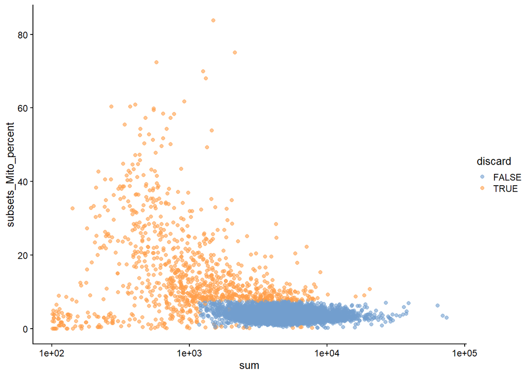

```r
plotColData(sce, x="sum", y="subsets_Mito_percent", colour_by = "discard") + scale_x_log10()
```

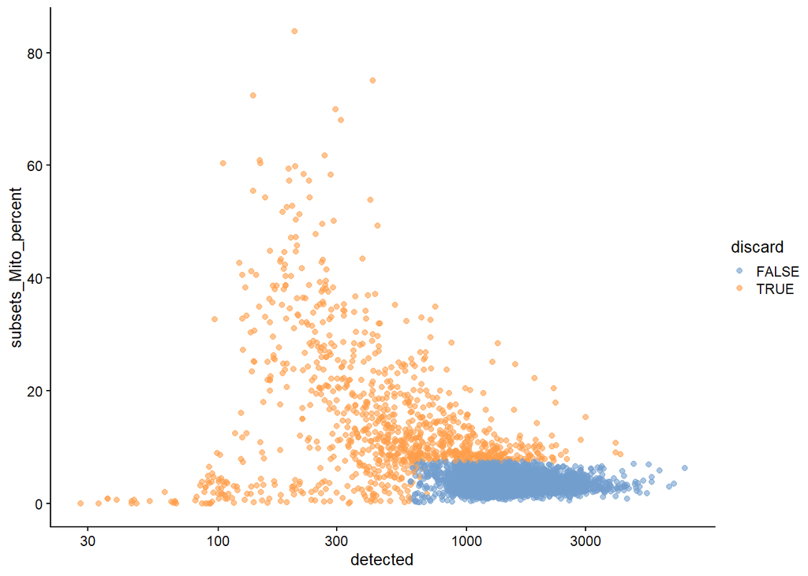

```r
plotColData(sce, x="detected", y="subsets_Mito_percent", colour_by = "discard") + scale_x_log10()
```

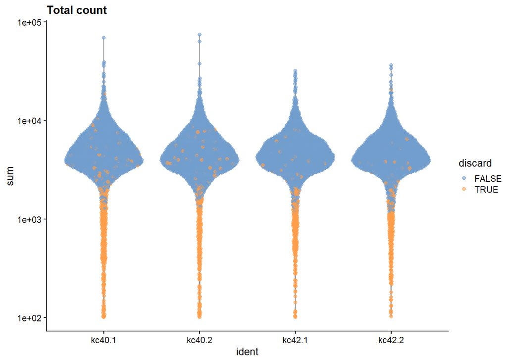

```r
plotColData(sce, x="ident", y="sum", colour_by="discard") +
        scale_y_log10() + ggtitle("Total count")
```

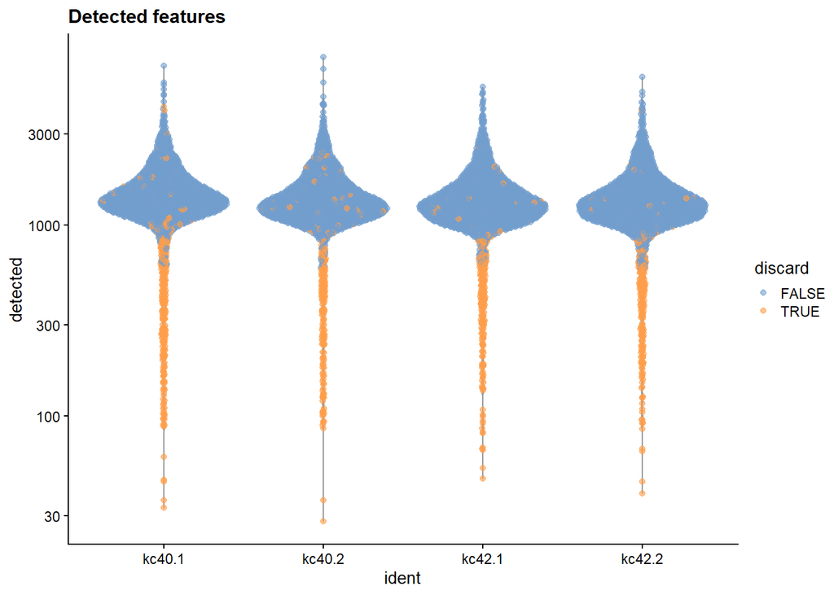

```r
plotColData(sce, x="ident", y="detected", colour_by="discard") +
        scale_y_log10() + ggtitle("Detected features")
```

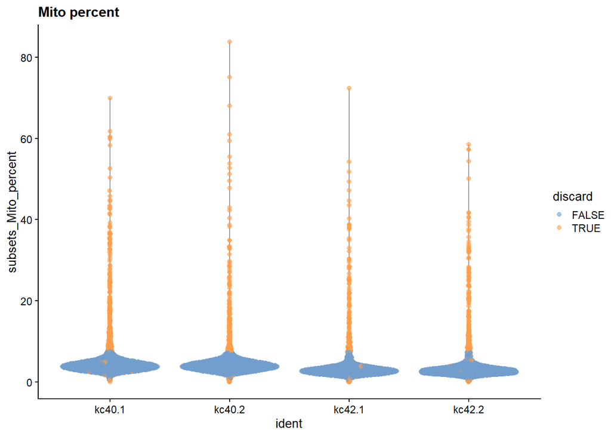

```r
plotColData(sce, x="ident", y="subsets_Mito_percent",
        colour_by="discard") + ggtitle("Mito percent")
```

Exploratory investigation of variance explained by metadata.

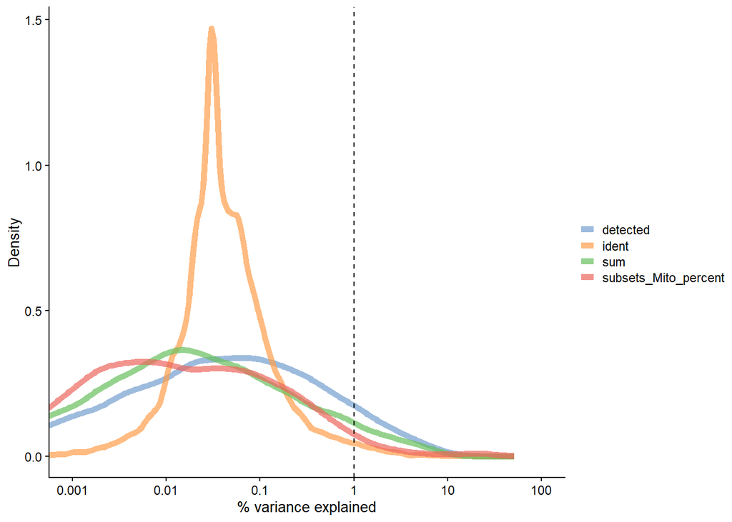

```r
vars <- getVarianceExplained(logNormCounts(sce),
    variables=c("ident", "subsets_Mito_percent", "sum", "detected"))
plotExplanatoryVariables(vars)
```

Subset to QC-filtered cells.

```r
# Keeping the columns we DON'T want to discard.
filtered <- sce[,!discard]
dropped <- as.numeric(summary(discard)["TRUE"])
kept <- as.numeric(summary(discard)["FALSE"])
print(paste0(dropped, " cells were filtered, yielding ", kept, " remaining cells"))
```

```
## [1] "1004 cells were filtered, yielding 8808 remaining cells"
```

Identify if a rare cell type might have been discarded.

```r
lost <- calculateAverage(counts(sce)[,!discard])
kept <- calculateAverage(counts(sce)[,discard])

logged <- cpm(cbind(lost, kept), log=TRUE, prior.count=2)
logFC <- logged[,1] - logged[,2]
abundance <- rowMeans(logged)
```

Blue points are mitochondrial genes and are expected to be downregulated. Exclusion of a cell type may be indicated by overexpression on this plot, of which there does not appear to be strong overexpression.

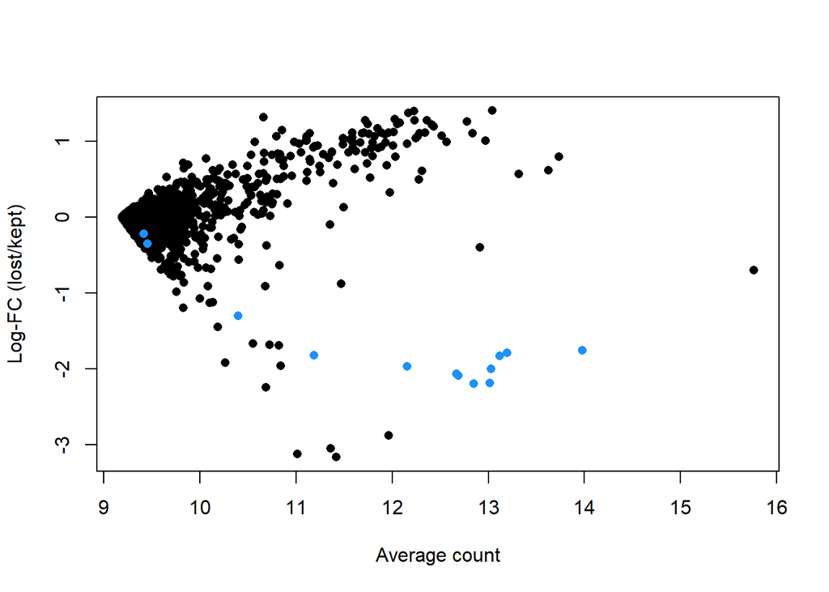

```r
plot(abundance, logFC, xlab="Average count", ylab="Log-FC (lost/kept)", pch=16)
points(abundance[is.mito], logFC[is.mito], col="dodgerblue", pch=16)
```

Convert to Seurat object for further preprocessing and analysis and save.

```r
kc <- as.Seurat(filtered)
#saveRDS(kc, paste0(data_dir, "placenta_scRNA_seq_kc_filtered_", Sys.Date(), ".rda"))
```

```r
# Rename Samples KC_40_1 and KC_40_2 have been renamed 1A and 1B; KC_42_1 and KC_42_2 <- 2A and 2B.
#levels(All@active.ident) <- c("Placenta 1A", "Placenta 1B", "Placenta 2A", "Placenta 2B")
```